# Exploratory data analysis of Lebanon conflict trends

Author

Sean Ng, Risk Anticipation Hub

Published

September 19, 2024

## Introduction

This is a primer on recent conflict in Lebanon, making use of the Armed Conflict Location and Event Data (ACLED). ACLED’s data collection in Lebanon began on 01 January 2016. UCDP might have more years of data (though fewer recorded events): that dataset will be evaluated later. This report contains data up to 13 September 2024. The most recent violence – the 2024 Lebanon pager explosions – have yet to be reflected in the ACLED dataset.

The gif below shows a month-by-month progression of political conflict and violence in Lebanon, Israel, Palestine, Jordan and Syria from January 2023 to the present day. For at least the past two years, Lebanon seems far more influenced by the conflict in Palestine and Israel than conflict in Syria – there is hardly any cross-border violence and Lebanon largely borders Assad-held areas, though there are many Syrian conflict actors operating within Lebanon.

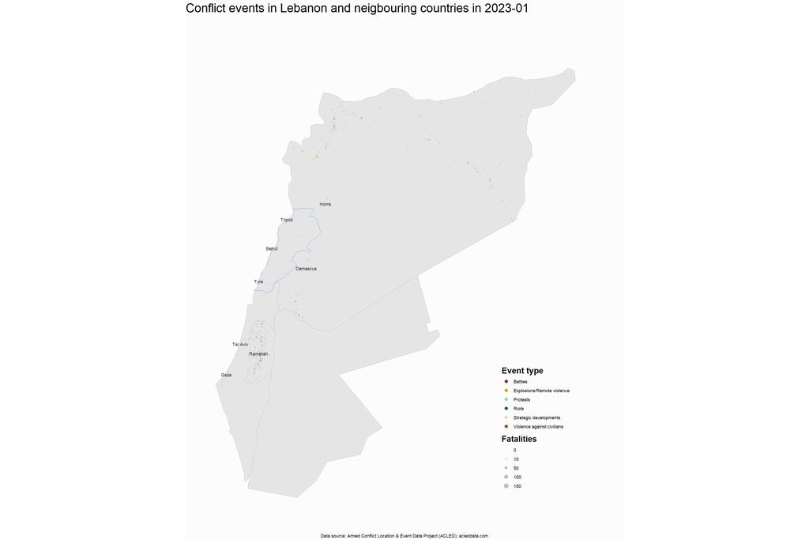

## Event types and fatalities

The charts below are streamgraphs, where values over time – in the case below, quarterly conflict events between 2016 and 2024 – are represented by the area. Though there are negative values shown, the Y-axis values are absolute; however, using a streamgraph, as opposed to an area graph, makes spikes in violence (from elections, for instance) much more visible.

From the chart below, sorted in order of number of **events** from political incidents per quarter, it seems that Lebanon is stuck in Israel and Palestine’s orbit, with each experiencing an upswing in violence in 2023, prior to the 7 October attacks. Prior to this, Lebanon had been had actually been in a period of stabilisation since 2019 and the overthrow of their then government. However, the current flavour of violence in Lebanon is very different from the October 17 revolution in 2019, looking more like a country at war.

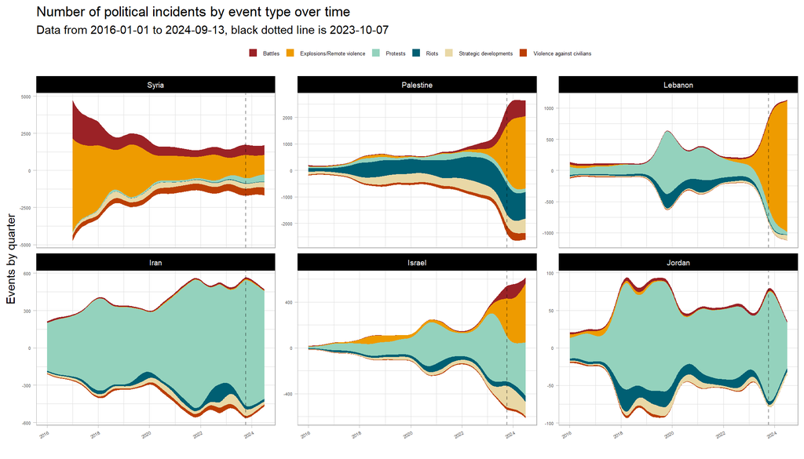

The streamgraphs below break down **fatalities** by event type.

Iran and Jordan have seen a lessening of pressure on their governments since 7 October 2023. The Iranian government has been under tremendous pressure, fending off mass protest and civil disobedience movements every year.

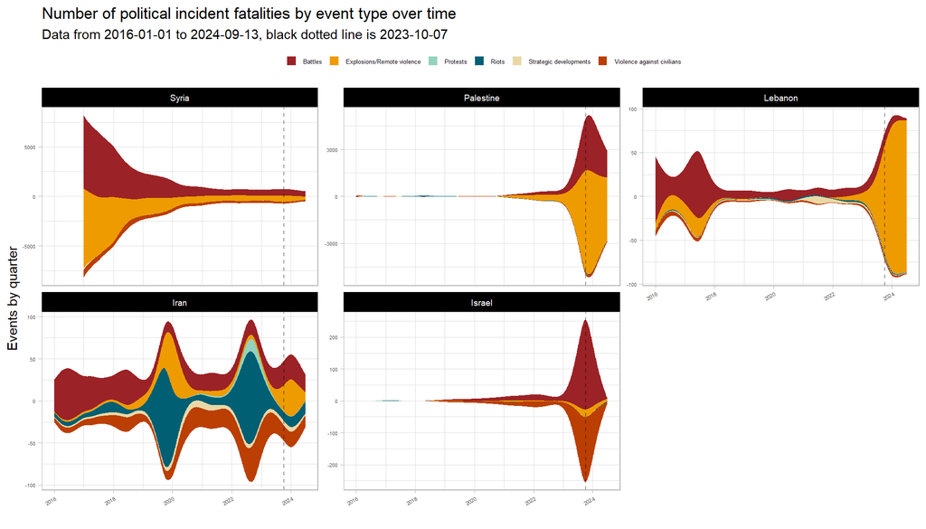

There was an escalation in tensions between Lebanon and Israel in 2023, prior to the October 7 attacks. But the pattern of violence in Lebanon is deeply changed, especially when compared to before October 7 2023.

As the plot below shows, Lebanon had previously been more widely-plagued by Syrian-linked militias, but as mentioned, it currently seems to be much more heavily involved in the Israel-Palestine conflict.

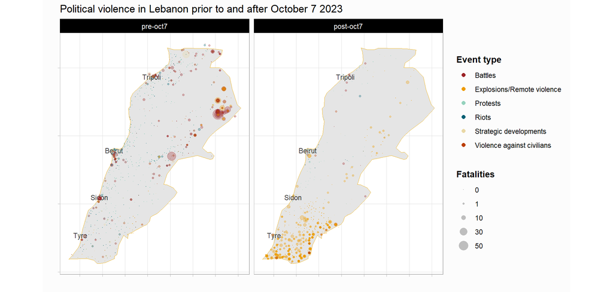

## Actors

Additionally, actors related to or originating from Israel or Palestine are highlighted in red, whilst the actors related to or originating from Syria are highlighted in gold. It would appear that Lebanon seems to be caught in the crosshairs of the two large regional conflicts, in line with conventional wisdom.

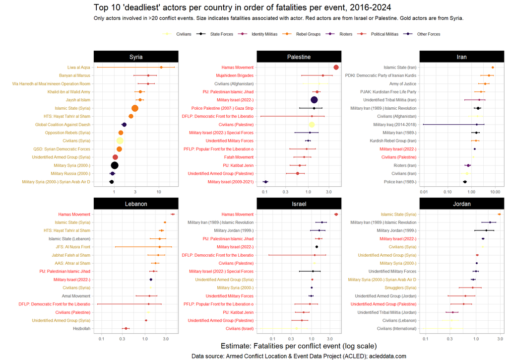

Longer error bars typically indicate higher uncertainty around the estimate, in the case of ACLED data, this means that there are comparatively fewer events for these actors compared to those with short error bars.

## Internally-displaced persons

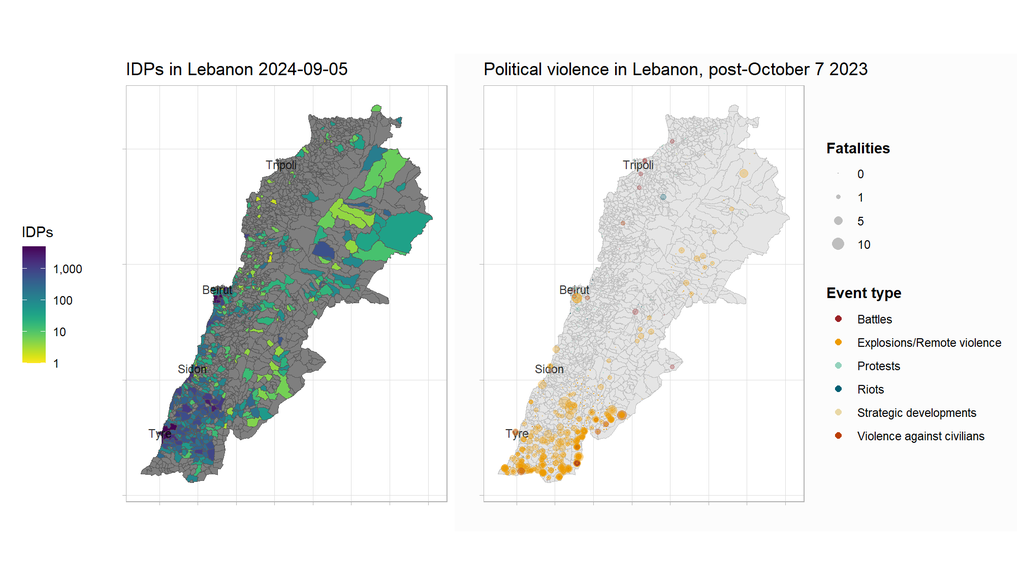

IDPs in Lebanon are located in the largest cities and in the belt between Tyre and Sidon near the Southern border. This is, unfortunately, very close to the bulk of the current conflict. These areas are primarily experiencing explosions and remote violence: Al Nabatieh and South Governorates both border Israel and have experienced numerous artillery attacks and drone strikes:

Breakdown of post Oct 7 2023 Explosions and Remote violence

| governorate | events | %events | fatalities | %fatalities |
| --- | --- | --- | --- | --- |
| Al Nabatieh | 5159 | 66 | 473 | 69 |
| South | 2567 | 33 | 171 | 25 |
| Baalbek-Hermel | 55 | 1 | 18 | 3 |
| Mount Lebanon | 4 | 0 | 17 | 2 |
| Bekaa | 15 | 0 | 11 | 2 |
| Akkar | 2 | 0 | 0 | 0 |
| North | 1 | 0 | 0 | 0 |

The carrying capacities of towns and cities in Southern Lebanon need to be more closely examined. Infrastructure and housing stock assessments are recommended for towns and cities in this area, to evaluate how ready these areas are to deal with additional displacement and identify priorities for recovery and reconstruction.

## Forecasts

Below are the three-, six- and twelve-month aggregate forecast for Lebanon and its neighbouring countries. Higher number or darker colours indicate higher levels of conflict.

The RAH aggregate – which has factored in ACLED, UCDP, VIEWS and CFB forecasts – predicts a relatively high level of violence in Lebanon, but still lower than Israel, Palestine and Syria. The forecasts also expect conflict to lessen within 12 months.

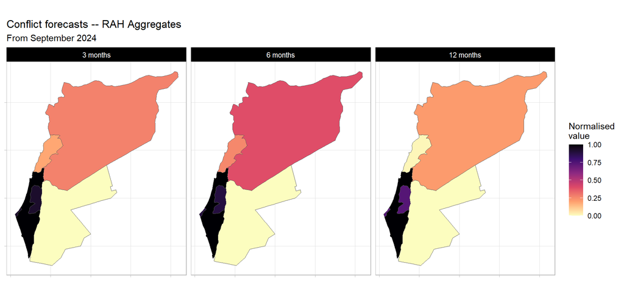

Of note, when viewing the individual three-month forecasts below, is the elevated risk of Explosions and Remote Violence in Lebanon. This is in line with what we have observed in earlier plots at the border with Israel. Explosive remnants of war (ERW) expertise will also be sorely needed.

My current read on these forecasts is that if the conflict with Israel expands beyond being primarily Explosions and Remote Violence, for instance, a ground invasion, we will need to redo these forecasts. Currently, the consensus for these forecasts seem to be de-escalation within 12 months.

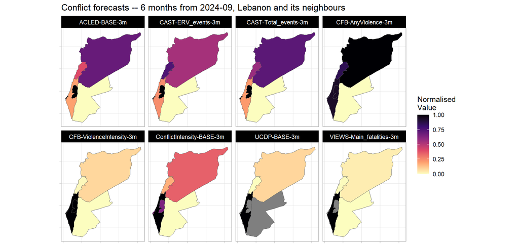